# DATA100 Introduction to Data Analytics

Lecture 11: Missing Values and Joins

Agassi Iu

Wilfrid Laurier University

2026-10-29

# The story so far

## Can we trust our survey?

**Two Questions**

Our sleep survey is not perfect. Some students skipped questions, and the caffeine facts live in a different table.

1. Can we trust our averages when people skip questions? (*Missing values*, Chapter 18)
2. Do students who drink more caffeine sleep less? (*Joins*, Chapter 19)

## Goal for today

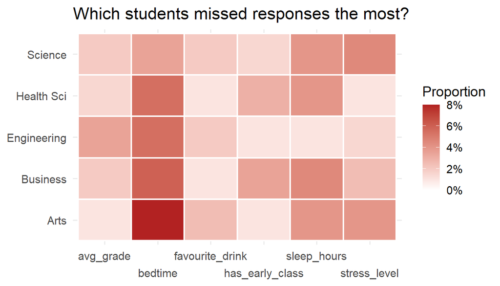

## Setup and data

We are bringing in another table: `drinks`, which includes information about beverages.

```r
library(dplyr); library(tidyr); library(tibble); library(readr)
library(ggplot2); library(stringr); library(forcats); library(lubridate)

survey <- read.csv("data/sleep_survey_v2.csv", na.strings = c("", "NA"),
                   fileEncoding = "WINDOWS-1252") |>
  as_tibble() |>
  mutate(survey_date = ymd_hms(survey_date))

drinks <- read.csv("data/drinks.csv", fileEncoding = "WINDOWS-1252") |>
  as_tibble()
```

## What is the `drinks` data?

```r
drinks
```

```
# A tibble: 7 × 4
  drink        serving_ml caffeine_mg sugary
  <chr>             <dbl>       <dbl> <chr>
1 Coffee              240          95 No
2 Energy drink        473         160 Yes
3 Tea                 240          47 No
4 Pop                 355          34 Yes
5 Water               500           0 No
6 Matcha              240          70 No
7 Bubble tea          500          50 Yes
```

**Not everything fits in this 80-minute lecture**

I may leave some of the undiscussed functions or tools in an *appendix table* at the end of the slide deck. Each row will say what the tool does and which section of the chapter to read. You should definitely take a look at the text for more details.

# Part 1: Missing values

## What are missing values?

|  | **Explicit** missing | **Implicit** missing |
| --- | --- | --- |
| Idea | The data has a cell and it says `NA` | The data has no row at all |
| Example from survey | A student left `sleep_hours` blank | Nobody answered between 3 and 4 AM, so that hour is not in the data |
| Another example | `stress_level` left blank | Matcha and Bubble tea: nobody chose them, so they never appear |
| How to see it | `is.na()`, `count()` | Compare with what should be there: `complete()`, `anti_join()` |
| How to fix it | `drop_na()`, `na.rm`, `coalesce()`, `replace_na()` | `complete()` adds the rows |

## A simple example

**Checkpoint**

## Example Continued

**Plots hide implicit gaps**

## Brief Review of `NA`

**`NA` is contagious**

An unknown value makes almost every answer unknown. - E.g. arithemtic like addition/subtraction - E.g. statistics like mean/median)

## Testing for `NA`

**What do we do?**

`NA == NA` is `NA`, so we can use `is.na()` to test for it

## Filtering

**Try running the following code**

Suppose that I collected these sleep survey response from 1000 students. I want to filter and count the number of students that sleep less than 6 hours on average, and then count the number of students that sleep for greater or equal to 6 hours per night. What are the results showing me?

[figure not shown]

## The `filter()` trap

**Caution**

The two counts do **not** add up to 1000! `filter()` drops rows where the condition is `NA`. Missing students vanish from **both** sides. So how many students did not had `NA` in the survey response?

## Blank vs `NA`

An empty cell is not always `NA`. It depends on how the file is read:

**No error, no warning**

With `na.strings = character()`, the 23 blanks become **empty text**, and `is.na()` finds none of them. The `na.strings` argument tells `read.csv()` which strings mean “missing”. We used `na.strings = c("", "NA")`.

## Missing in disguise

What about `idk`, `varies` and `n/a`? They are not blank, but they carry **no information**:

- We can use `regex` (regular expressions) from Lecture 10 to find them: i.e. no digit, and not `midnight`.
- Decide what counts as missing, and write it down

## A representation for `NA`?

**`na_if()`**

This function allows you to transform a *single* value that implies *missing* (e.g an extreme value like `-99`), and turn it into `NA`.

## Where is the missing?

```r
survey |>
  mutate(
    bedtime = if_else(
      str_detect(bedtime, regex("\\d|midnight", ignore_case = TRUE)),
      bedtime, NA_character_
    )
  ) |>
  select(program, sleep_hours, stress_level, favourite_drink,
         has_early_class, avg_grade, bedtime) |>
  mutate(across(-program, is.na)) |>
  group_by(program) |>
  summarize(across(everything(), mean)) |>
  pivot_longer(-program, names_to = "question", values_to = "share") |>
  ggplot(aes(x = question, y = program, fill = share)) +
  geom_tile(colour = "white", linewidth = 0.8) +
  scale_x_discrete(guide = guide_axis(n.dodge = 2)) +
  scale_fill_gradient(
    low = "white", high = "firebrick",
    limits = c(0, NA),
    labels = scales::percent,
    name = "Proportion"
  ) +
  labs(title = "Which students missed responses the most?", x = NULL, y = NULL) +
  theme_minimal(base_size = 14)
```

## A heat map

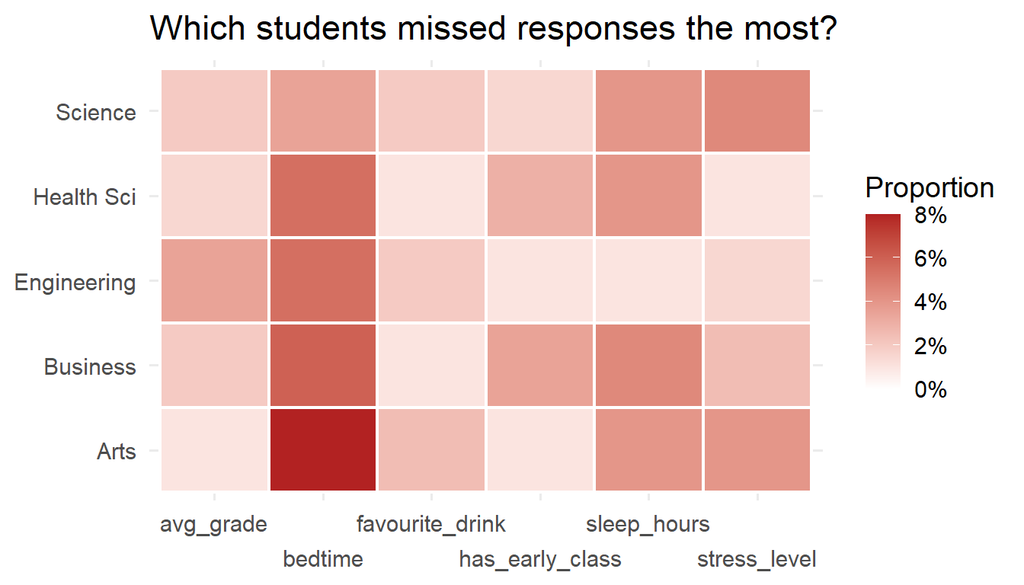

## Does the missing matter?

**Tip**

Suppose that you want to compare students who answered with students who did not. Did the *missing data* affect your results?

## Observations

**missing looks *random***

**Random is not guaranteed**

If stressed students skip the stress question, dropping them makes everyone look calmer. Always ask **who** is missing, not just **how many**.

## Handling missing values

| Tool | What it does |
| --- | --- |
| `na.rm = TRUE` | Ignore the `NA`s inside one calculation |
| `drop_na()` | Remove the **rows** that have `NA` |
| `replace_na()` | Replace `NA` with a value you choose |
| `coalesce()` | Take the first value that is not `NA` |

## Different ways to find the mean

## Imputation

**Definition**

Imputation means filling in a missing value with an estimate.

- **Fixed value**: a number you choose, such as `0`
- **Mean**: the average of the answers we have (**mean imputation**)
- **Last value**: the last known value above it

**It comes with a cost**

Filling with the mean keeps the average but shrinks the spread (`sd`), and it makes 35 students look more typical than they are. Dropping rows loses students. There is no free option, so choose, and say which.

## Exercise 1

**Live exercise**

Work with the five questions `sleep_hours`, `stress_level`, `favourite_drink`, `has_early_class` and `avg_grade`.

1. How many students are missing at least one of the five?
2. Which program has the most missing `avg_grade`s?

## When did the students respond to the survey?

**Implicit missing**

When we show a (line) plot, the lines connect the hours before and after each gap. So in fact, it hides the hours (timeslot) when nobody answered in the survey.

## Filling in the missing rows

**`complete()`**

This function adds the rows that are missing from a table. You tell it which values should exist, and it creates a row for every one that’s absent, and `fill` the other columns with `NA` or a value that you choose.

## Empty groups

A group with **no rows** is also implicit missing. `group_by(.drop = FALSE)` keeps every level of a factor:

- Without `.drop = FALSE`, Matcha and Bubble tea would not appear at all
- When we learned about “Factors” from last week, we know that we should keep track of the levels that **should** be there

## Exercise 2

**Live exercise**

Responses per weekday. Wednesday is missing from the table.

1. Add the missing row, with `0` responses.
2. Replace the `NA` in `n` with `0`.

# Part 2: Joins

## Does caffeine cost us sleep?

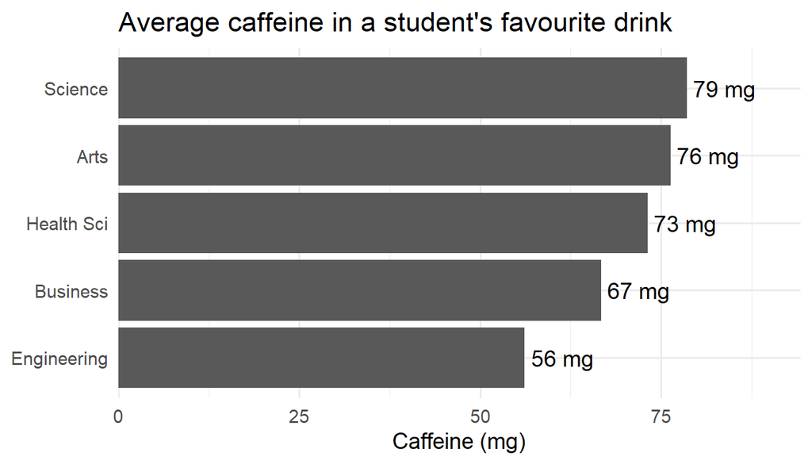

## Answering one question using two tables

| Step | Tool (Chapter 19) |
| --- | --- |
| Find the matching column | *Keys*: `favourite_drink` and `drink` |
| Add columns from another table | `left_join()`, `join_by()` |
| Other ways to combine | `inner_join()`, `full_join()` |
| Check what did not match | `anti_join()`, `semi_join()` |

## The two tables

- The survey has the drink name, and the drinks table has the facts
- The shared information is the drink name: that is the **key**

## Keys

**Primary Key**

A primary key is a column whose values are unique: no two rows share one, so each value picks out exactly one row. E.g.

- `student_id` in `survey`: each ID is one student
- The `drink` column in the `drinks` table: “Coffee” appears in one row only

**Foreign Key**

A foreign key is a column in another table that holds those same values. - `favourite_drink` in `survey` holds drink names like “Coffee” - Many students can share the same favourite drink like coffee

## Combining tables

**`left_join()`**

The function `left_join(x, y)` keeps every row of `x` and adds the matching columns of `y`. In the end, you will get the same number of rows but more columns (more information you learn about each observation).

- You can also use `join_by(a == b)` to say which column in `x` matches with which column in `y`

## What about students with no drink?

- No drink means no match, so `caffeine_mg` is `NA`
- This is Part 1 again: explicit missing, created by the join

## Sleep and caffeine

```r
survey_drinks |>
  filter(!is.na(favourite_drink)) |>
  group_by(favourite_drink, caffeine_mg) |>
  summarize(mean_sleep = mean(sleep_hours, na.rm = TRUE), .groups = "drop") |>
  mutate(favourite_drink = fct_reorder(favourite_drink, mean_sleep)) |>
  ggplot(aes(x = mean_sleep, y = favourite_drink)) +
  geom_col() +
  geom_text(
    aes(label = paste0(round(mean_sleep, 1), " h  (", caffeine_mg, " mg)")),
    hjust = -0.1
  ) +
  scale_x_continuous(expand = expansion(mult = c(0, 0.3))) +
  labs(
    title = "Average sleep by favourite drink, with its caffeine",
    x = "Average hours of sleep", y = NULL
  ) +
  theme_minimal(base_size = 14)
```

## Is this what you expected?

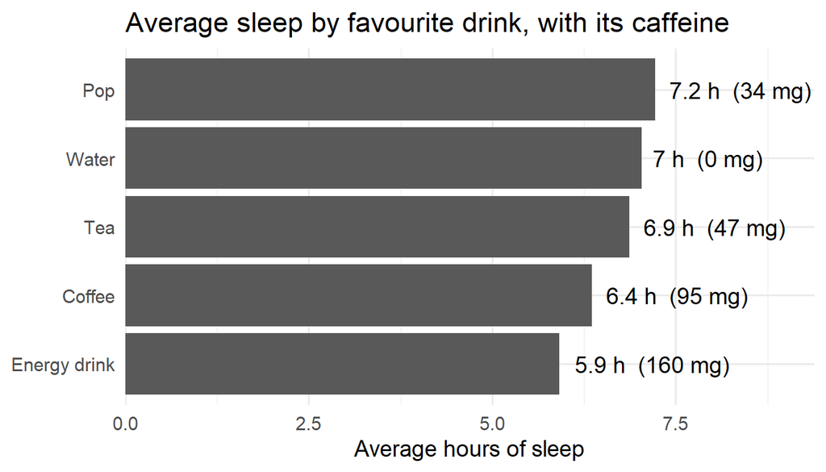

**Association, not cause**

Students who drink energy drinks also differ in workload and program. The chart shows a pattern, not what causes it.

## Different types of “joins”

| Join | What The Table Keeps |
| --- | --- |
| `inner_join()` | Only rows with a match in both |
| `left_join()` | All rows of `x`, plus matches from `y` |
| `full_join()` | All rows of both |

## Filtering joins

**Who did not match?**

`anti_join()` keeps the rows of `x` with **no match** in `y`.

`semi_join()` keeps the rows **with** a match.

## What changed?

**Using Joins to find implicit missing**

Matcha and Bubble tea were never in the survey: **implicit** missing. Filtering joins *did not add any columns*. They only filter rows.

## Caffeine by early class

```r
survey_drinks |>
  filter(!is.na(has_early_class), !is.na(caffeine_mg)) |>
  mutate(group = if_else(has_early_class == "Yes", "Early class", "No early class")) |>
  group_by(group) |>
  summarize(mean_caffeine = mean(caffeine_mg)) |>
  ggplot(aes(x = mean_caffeine, y = group)) +
  geom_col() +
  geom_text(aes(label = paste(round(mean_caffeine), "mg")), hjust = -0.1) +
  scale_x_continuous(expand = expansion(mult = c(0, 0.2))) +
  labs(
    title = "Early-class students pick stronger drinks",
    x = "Average caffeine (mg)", y = NULL
  ) +
  theme_minimal(base_size = 14)
```

## Students with early classes need caffeine?

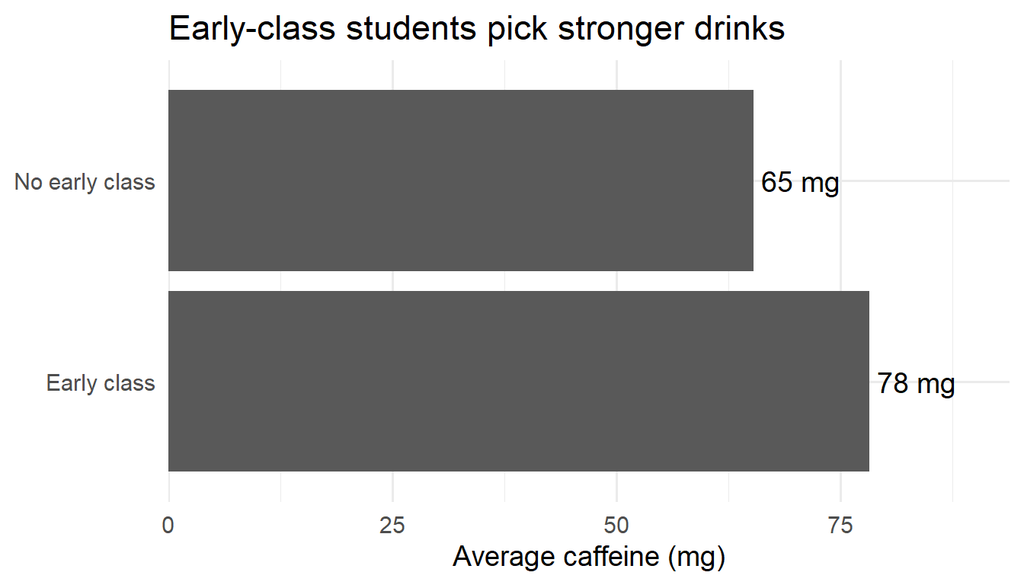

## Exercise 3

**Live exercise**

1. Join `drinks` to the survey and compute the proportion of students who chose a sugary drink, for each program. Ignore students with no drink.
2. How many students chose a drink that has more than 100 mg of caffeine?

# Wrap-up

## Back to the story

| Question | Chapter | Tools we used |
| --- | --- | --- |
| Can we trust our averages? | *Missing values* | `is.na()`, `na.rm`, `drop_na()`, `replace_na()`, `na_if()`, `complete()` |
| Do students who drink more caffeine sleep less? | *Joins* | `left_join()`, `join_by()`, `anti_join()`, `semi_join()` |

## Sources

**Attribution**

Content adapted from *R for Data Science (2e)* by Hadley Wickham, Mine Çetinkaya-Rundel, and Garrett Grolemund:

- Chapter 18: Missing values, https://r4ds.hadley.nz/missing-values.html
- Chapter 19: Joins, https://r4ds.hadley.nz/joins.html

# Appendix: read the text

## Missing values: other tools (i)

| Tool | What it does | Tiny example | Read the section on |
| --- | --- | --- | --- |
| `fill()` | Fills `NA`s with the last value above (or below) | `fill(df, n, .direction = "down")` | Last observation carried forward |
| `coalesce()` | First value that is not `NA` | `coalesce(x, 0)` | Fixed values |
| `NaN`, `is.nan()` | “Not a number”, for example `0 / 0` | `is.nan(0 / 0)` | NaN |
| `drop_na()` with columns | Drops only rows missing **those** columns | `drop_na(df, avg_grade)` | Explicit missing values |

## Missing values: other tools (ii)

| Tool | What it does | Tiny example | Read the section on |
| --- | --- | --- | --- |
| `if_any()`, `if_all()` | Tests a condition across several columns | `filter(if_any(a:c, is.na))` | Explicit missing values |
| `complete()` with `nesting()` | Adds only the combinations that make sense | `complete(df, nesting(a, b))` | Implicit missing values |
| `anti_join()` | Finds implicit gaps by comparing with a full list | `anti_join(all_days, df)` | Implicit missing values |

## Missing values: other tools (iii)

| Tool | What it does | Tiny example | Read the section on |
| --- | --- | --- | --- |
| `.drop = FALSE` | Keeps empty groups in `group_by()` | `group_by(f, .drop = FALSE)` | Factors and empty groups |
| `scale_x_discrete(drop = FALSE)` | Keeps empty levels on a plot axis | `scale_x_discrete(drop = FALSE)` | Factors and empty groups |

## Joins: other tools (i)

| Tool | What it does | Tiny example | Read the section on |
| --- | --- | --- | --- |
| `right_join()` | Keeps **all** rows of `y` | `right_join(x, y, by = "key")` | Mutating joins |
| `by = join_by(a == b)` | Matches columns with different names | `join_by(drink == favourite_drink)` | Specifying join keys |
| `suffix` | Renames columns with the same name | `left_join(x, y, suffix = c("_x", "_y"))` | Specifying join keys |
| `relationship`, `multiple` | Checks and controls many-to-many matches | `left_join(x, y, relationship = "many-to-one")` | How do joins work? |
| `unmatched = "error"` | Stops if a row has no match | `inner_join(x, y, unmatched = "error")` | Specifying join keys |

## Joins: other tools (ii)

| Tool | What it does | Tiny example | Read the section on |
| --- | --- | --- | --- |
| `cross_join()` | Every row of `x` with every row of `y` | `cross_join(x, y)` | Cross joins |
| Inequality joins | Match with `<`, `<=`, `>`, `>=` | `join_by(date >= start)` | Filtering joins |
| Rolling joins | Match with the **closest** value | `join_by(closest(date >= start))` | Rolling joins |
| Overlap joins | Match ranges that overlap | `join_by(overlaps(a, b, c, d))` | Overlap joins |
| Surrogate keys | A made-up key, such as `row_number()` | `mutate(id = row_number())` | Primary and foreign keys |